# Cluster then Predict

In this illustration, we will cluster our data before constructing predictive models.

# Data

## Read Data

You must read the data before trying to run code on your own machine. To read data use the following code after setting your working directory. To set your working directory, modify the following to set the file path for the folder where the data file resides. setwd(’c:/thatawesomeclass/)

```r
wine = read.table('wine.csv',header=TRUE,sep=';')
```

## Explore Data

This dataset contains information on chemical properties of a set of wines (e.g., fixed acidity, alcohol) and a rating of quality.

```r
str(wine)
```

```
## 'data.frame':    4898 obs. of  12 variables:
##  $ fixed.acidity       : num  7 6.3 8.1 7.2 7.2 8.1 6.2 7 6.3 8.1 ...
##  $ volatile.acidity    : num  0.27 0.3 0.28 0.23 0.23 0.28 0.32 0.27 0.3 0.22 ...
##  $ citric.acid         : num  0.36 0.34 0.4 0.32 0.32 0.4 0.16 0.36 0.34 0.43 ...
##  $ residual.sugar      : num  20.7 1.6 6.9 8.5 8.5 6.9 7 20.7 1.6 1.5 ...
##  $ chlorides           : num  0.045 0.049 0.05 0.058 0.058 0.05 0.045 0.045 0.049 0.044 ...
##  $ free.sulfur.dioxide : num  45 14 30 47 47 30 30 45 14 28 ...
##  $ total.sulfur.dioxide: num  170 132 97 186 186 97 136 170 132 129 ...
##  $ density             : num  1.001 0.994 0.995 0.996 0.996 ...
##  $ pH                  : num  3 3.3 3.26 3.19 3.19 3.26 3.18 3 3.3 3.22 ...
##  $ sulphates           : num  0.45 0.49 0.44 0.4 0.4 0.44 0.47 0.45 0.49 0.45 ...
##  $ alcohol             : num  8.8 9.5 10.1 9.9 9.9 10.1 9.6 8.8 9.5 11 ...
##  $ quality             : int  6 6 6 6 6 6 6 6 6 6 ...
```

## Split Data

```r
library(caret)
set.seed(1706)
split = createDataPartition(y=wine$quality,p = 0.7,list = F,groups = 100)
train = wine[split,]
test = wine[-split,]
```

# Predict Using Regression

```r
linear = lm(quality~.,train)
summary(linear)
```

```
##
## Call:
## lm(formula = quality ~ ., data = train)
##
## Residuals:
##     Min      1Q  Median      3Q     Max
## -3.8275 -0.4929 -0.0384  0.4640  3.0883
##
## Coefficients:
##                        Estimate Std. Error t value Pr(>|t|)
## (Intercept)           1.590e+02  2.132e+01   7.458 1.11e-13 ***
## fixed.acidity         7.730e-02  2.476e-02   3.122  0.00181 **
## volatile.acidity     -1.918e+00  1.382e-01 -13.877  < 2e-16 ***
## citric.acid           3.931e-02  1.143e-01   0.344  0.73092
## residual.sugar        8.751e-02  8.746e-03  10.006  < 2e-16 ***
## chlorides             1.878e-01  6.814e-01   0.276  0.78284
## free.sulfur.dioxide   4.252e-03  9.986e-04   4.258 2.12e-05 ***
## total.sulfur.dioxide -7.686e-04  4.459e-04  -1.724  0.08484 .
## density              -1.593e+02  2.165e+01  -7.360 2.29e-13 ***
## pH                    7.509e-01  1.264e-01   5.939 3.15e-09 ***
## sulphates             7.120e-01  1.195e-01   5.960 2.78e-09 ***
## alcohol               1.782e-01  2.754e-02   6.472 1.10e-10 ***
## ---
## Signif. codes:  0 '***' 0.001 '**' 0.01 '*' 0.05 '.' 0.1 ' ' 1
##
## Residual standard error: 0.7549 on 3419 degrees of freedom
## Multiple R-squared:  0.2781, Adjusted R-squared:  0.2757
## F-statistic: 119.7 on 11 and 3419 DF,  p-value: < 2.2e-16
```

```r
sseLinear = sum(linear$residuals^2); sseLinear
```

```
## [1] 1948.546
```

```r
predLinear = predict(linear,newdata=test)
sseLinear = sum((predLinear-test$quality)^2); sseLinear
```

```
## [1] 812.489
```

# Cluster then Predict using Regression

Let us cluster first and then run a model to see if there is an improvement. To cluster the wines, we have to remove the outcome variable

```r
trainMinusDV = subset(train,select=-c(quality))
testMinusDV = subset(test,select=-c(quality))
```

## Prepare Data for Clustering

Cluster Analysis is sensitive to scale. Standardize the data.

```r
library(caret)
preproc = preProcess(trainMinusDV)
trainNorm = predict(preproc,trainMinusDV)
testNorm = predict(preproc,testMinusDV)
mean(trainNorm$chlorides)
```

```
## [1] 6.795492e-17
```

```r
mean(testNorm$chlorides)
```

```
## [1] 0.03580296
```

## Hierarchical Cluster Analysis

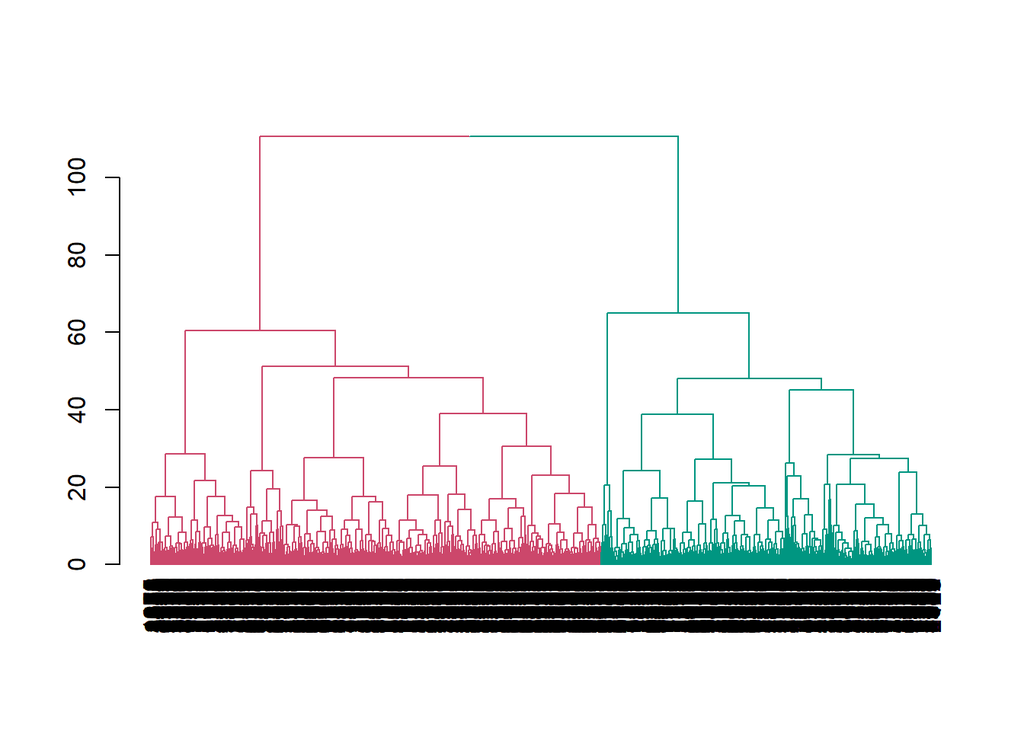

```r
distances = dist(trainNorm,method = 'euclidean')
clusters = hclust(d = distances,method = 'ward.D2')

library(dendextend)
plot(color_branches(as.dendrogram(clusters), k=2, groupLabels = F))
```

```r
h_segments = cutree(clusters,k=2)
table(h_segments)
```

```
## h_segments
##    1    2
## 1981 1450
```

### Visualize

To express the clusters on a scatterplot, we flatten the data with eleven variables into 2 dimensions by conducting a factor analysis with varimax rotation. This is done because it is not possible to visualize 11-dimensional data.

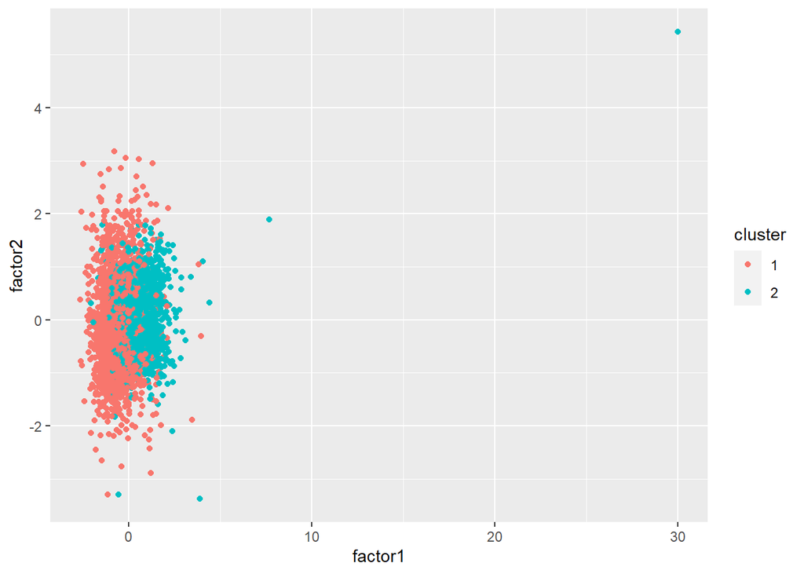

```r
library(psych)
temp = data.frame(cluster = factor(h_segments),
           factor1 = fa(trainNorm,nfactors =2, rotate ='varimax')$scores[,1],
           factor2 = fa(trainNorm,nfactors =2, rotate ='varimax')$scores[,2])

library(ggplot2)
ggplot(temp,aes(x=factor1,y=factor2,col=cluster))+
  geom_point()
```

## k-means Clustering

```r
set.seed(1706)
km = kmeans(x=trainNorm, centers=2,iter.max=10000, nstart=100)
k_segments = km$cluster
table(k_segments)
```

```
## k_segments
##    1    2
## 1359 2072
```

Let’s us compare the two-cluster solutions obtained from hierarchical cluster to k-means.

```r
table(h_segments)
```

```
## h_segments
##    1    2
## 1981 1450
```

```r
table(k_segments)
```

```
## k_segments
##    1    2
## 1359 2072
```

```r
table(h_segments,k_segments)
```

```
##           k_segments
## h_segments    1    2
##          1  190 1791
##          2 1169  281
```

```r
mean(k_segments==h_segments) # %match between results of hclust and kmeans
```

```
## [1] 0.1372778
```

```r
min(sum(h_segments==k_segments),
    sum(h_segments!=k_segments))
```

```
## [1] 471
```

```r
max(sum(h_segments==k_segments),
    sum(h_segments!=k_segments))
```

```
## [1] 2960
```

### Total within sum of squares Plot

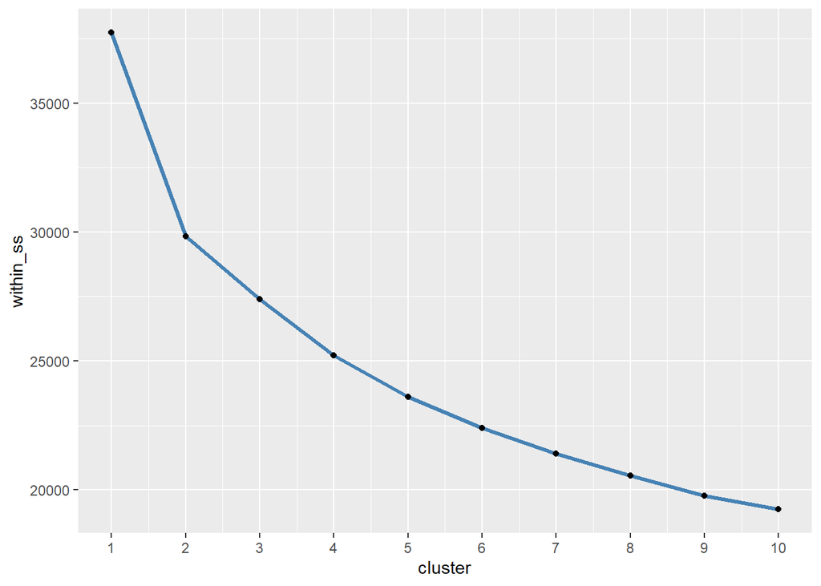

```r
within_ss = sapply(1:10,FUN = function(x) kmeans(x=trainNorm, centers = x,
                                                 iter.max=1000, nstart=25)$tot.withinss)

ggplot(data=data.frame(cluster = 1:10,within_ss),aes(x=cluster,y=within_ss))+
  geom_line(col='steelblue',size=1.2)+
  geom_point()+
  scale_x_continuous(breaks=seq(1,10,1))
```

### Ratio Plot

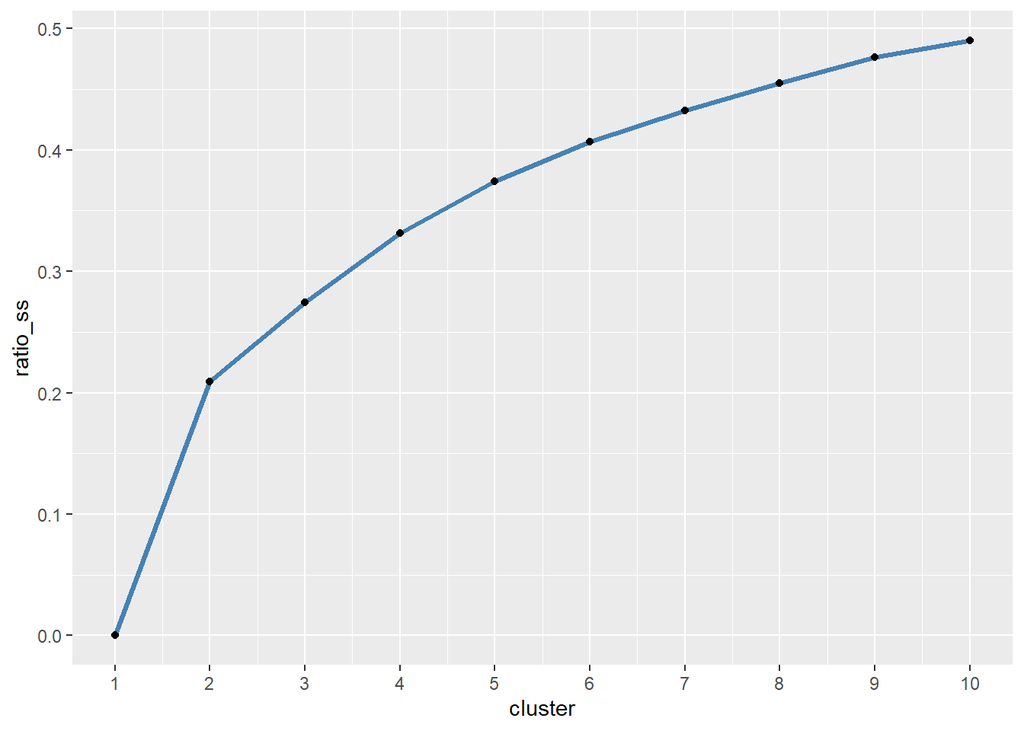

```r
ratio_ss = sapply(1:10,FUN = function(x) {km=kmeans(x=trainNorm, centers = x,
                                                  iter.max=1000, nstart=25)
                                          km$betweenss/km$totss})

ggplot(data=data.frame(cluster = 1:10,ratio_ss),aes(x=cluster,y=ratio_ss))+
  geom_line(col='steelblue',size=1.2)+
  geom_point()+
  scale_x_continuous(breaks=seq(1,10,1))
```

### Silhouette Plot

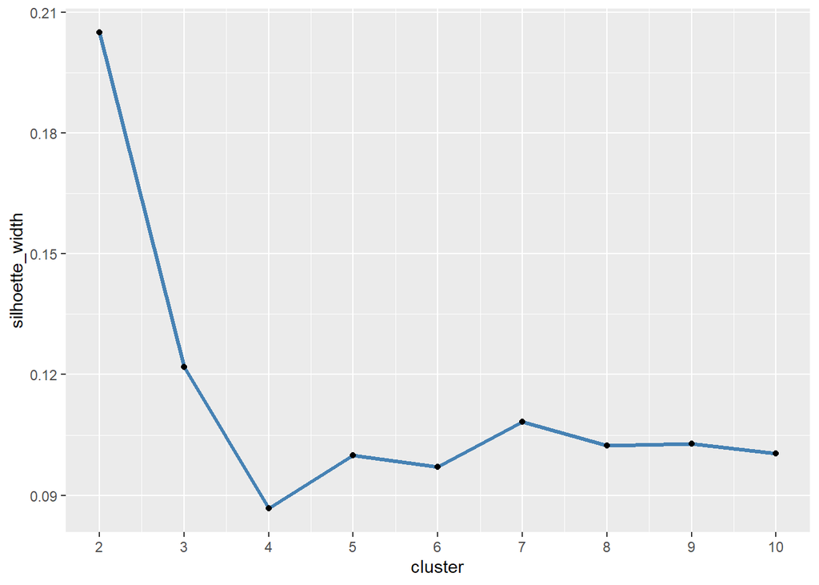

```r
library(cluster)
silhoette_width = sapply(2:10,FUN = function(x) pam(x=trainNorm, k=x)$silinfo$avg.width)

ggplot(data=data.frame(cluster = 2:10,silhoette_width),aes(x=cluster,y=silhoette_width))+
  geom_line(col='steelblue',size=1.2)+
  geom_point()+
  scale_x_continuous(breaks=seq(2,10,1))
```

Both, the elbow plot and silhoette plot recommend a two-cluster solution, so we will group the data into two clusters.

```r
set.seed(1706)
km = kmeans(x = trainNorm,centers = 2,iter.max=10000,nstart=100)
```

## Apply Clustering Solution from Train to Test

```r
library(flexclust)
km_kcca = as.kcca(km,trainNorm) # flexclust uses objects of the classes kcca
clusterTrain = predict(km_kcca)
clusterTest = predict(km_kcca,newdata=testNorm)
```

Distribution of wines across clusters in Train

```r
table(clusterTrain)
```

```
## clusterTrain
##    1    2
## 1359 2072
```

Distribution of wines across clusters in Test

```r
table(clusterTest)
```

```
## clusterTest
##   1   2
## 588 879
```

## Split Train and Test Based on Cluster Membership

```r
train1 = subset(train,clusterTrain==1)
train2 = subset(train,clusterTrain==2)

test1 = subset(test,clusterTest==1)
test2 = subset(test,clusterTest==2)
```

## Predict for Each Cluster then Combine

```r
lm1 = lm(quality~.,train1)
lm2 = lm(quality~.,train2)
pred1 = predict(lm1,newdata=test1)
pred2 = predict(lm2,newdata=test2)
sse1 = sum((test1$quality-pred1)^2); sse1
```

```
## [1] 275.1254
```

```r
sse2 = sum((test2$quality-pred2)^2); sse2
```

```
## [1] 510.5178
```

```r
predOverall = c(pred1,pred2)
qualityOverall = c(test1$quality,test2$quality)
sseOverall = sum((predOverall - qualityOverall)^2); sseOverall
```

```
## [1] 785.6432
```

# Compare Results

Let us compare the sse for model on the entire data to the sse for models on clusters.

```r
paste('SSE for model on entire data',sseLinear)
```

```
## [1] "SSE for model on entire data 812.489032059707"
```

```r
paste('SSE for model on clusters',sseOverall)
```

```
## [1] "SSE for model on clusters 785.643176502731"
```

# Predict Using Tree

```r
library(rpart)
library(rpart.plot)
tree = rpart(quality~.,train,minbucket=10)
predTree = predict(tree,newdata=test)
sseTree = sum((predTree - test$quality)^2); sseTree
```

```
## [1] 866.0674
```

# Cluster then Predict Using Tree

```r
tree1 = rpart(quality~.,train1,minbucket=10)
tree2 = rpart(quality~.,train2,minbucket=10)
pred1 = predict(tree1,newdata=test1)
pred2 = predict(tree2,newdata=test2)
sse1 = sum((test1$quality-pred1)^2); sse1
```

```
## [1] 268.4452
```

```r
sse2 = sum((test2$quality-pred2)^2); sse2
```

```
## [1] 553.1455
```

```r
predTreeCombine = c(pred1,pred2)
qualityOverall = c(test1$quality,test2$quality)
sseTreeCombine = sum((predTreeCombine - qualityOverall)^2); sseTreeCombine
```

```
## [1] 821.5907
```

# Compare Results

Let us compare the sse for model on the entire data to the sse for models on clusters.

```r
paste('SSE for model on entire data',sseTree)
```

```
## [1] "SSE for model on entire data 866.06744900816"
```

```r
paste('SSE for model on clusters',sseTreeCombine)
```

```
## [1] "SSE for model on clusters 821.590740434687"
```

This file was generated using R Version 4.1.2